# project_code

```python
# Read data sets on ETF and mutual funds
# Identify a historical financial dataset including a measure of financial risk
import pandas as pd
etf = pd.read_csv("/Users/ishaanbabbar/6400-Project-Group2/data/ETFs.csv")
etf.head()
```

|  | fund_symbol | quote_type | region | fund_short_name | fund_long_name | currency | fund_category | fund_family | exchange_code | exchange_name | ... | fund_stdev_5years | fund_sharpe_ratio_5years | fund_treynor_ratio_5years | fund_alpha_10years | fund_beta_10years | fund_mean_annual_return_10years | fund_r_squared_10years | fund_stdev_10years | fund_sharpe_ratio_10years | fund_treynor_ratio_10years |
| --- | --- | --- | --- | --- | --- | --- | --- | --- | --- | --- | --- | --- | --- | --- | --- | --- | --- | --- | --- | --- | --- |
| 0 | AAAU | ETF | US | DWS RREEF Real Assets Fund - Cl | DWS RREEF Real Assets Fund - Class A | USD | NaN | DWS | PCX | NYSEArca | ... | NaN | NaN | NaN | NaN | NaN | NaN | NaN | NaN | NaN | NaN |
| 1 | AADR | ETF | US | AllianzGI Health Sciences Fund | Virtus AllianzGI Health Sciences Fund Class P | USD | Foreign Large Growth | Virtus | NGM | NasdaqGM | ... | 19.30 | 0.62 | 9.66 | 3.32 | 0.96 | 0.79 | 73.64 | 16.78 | 0.53 | 8.15 |
| 2 | AAXJ | ETF | US | NaN | American Century One Choice Blend+ 2015 Portfo... | USD | Pacific/Asia ex-Japan Stk | American Century Investments | NGM | NasdaqGM | ... | 15.91 | 0.66 | 10.37 | 0.30 | 0.99 | 0.55 | 78.24 | 16.83 | 0.36 | 4.81 |
| 3 | ABEQ | ETF | US | Thrivent Large Cap Growth Fund | Thrivent Large Cap Growth Fund Class A | USD | Large Value | Thrivent Funds | PCX | NYSEArca | ... | NaN | NaN | NaN | NaN | NaN | NaN | NaN | NaN | NaN | NaN |
| 4 | ACES | ETF | US | NaN | American Century One Choice Blend+ 2015 Portfo... | USD | Miscellaneous Sector | American Century Investments | PCX | NYSEArca | ... | NaN | NaN | NaN | NaN | NaN | NaN | NaN | NaN | NaN | NaN |

5 rows × 142 columns

```python
# Read data on mutual funds
m_funds = pd.read_csv("/Users/ishaanbabbar/6400-Project-Group2/data/MutualFunds.csv")
m_funds.head()
```

|  | fund_symbol | quote_type | region | fund_short_name | fund_long_name | currency | initial_investment | subsequent_investment | fund_category | fund_family | ... | peer_environment_avg | peer_environment_max | social_score | peer_social_min | peer_social_avg | peer_social_max | governance_score | peer_governance_min | peer_governance_avg | peer_governance_max |
| --- | --- | --- | --- | --- | --- | --- | --- | --- | --- | --- | --- | --- | --- | --- | --- | --- | --- | --- | --- | --- | --- |
| 0 | AAAAX | MutualFund | US | DWS RREEF Real Assets Fund - Cl | DWS RREEF Real Assets Fund - Class A | USD | 1000.0 | 50.0 | World Allocation | DWS | ... | 5.05 | 10.58 | 7.43 | 5.98 | 9.07 | 11.30 | 5.43 | 4.26 | 7.14 | 8.11 |
| 1 | AAAEX | MutualFund | US | AllianzGI Health Sciences Fund | Virtus AllianzGI Health Sciences Fund Class P | USD | 1000000.0 | NaN | Health | Virtus | ... | 1.43 | 3.27 | 12.96 | 9.52 | 12.87 | 15.08 | 8.40 | 4.96 | 7.68 | 10.30 |
| 2 | AAAFX | MutualFund | US | NaN | American Century One Choice Blend+ 2015 Portfo... | USD | 2500.0 | 50.0 | Target-Date 2015 | American Century Investments | ... | NaN | NaN | NaN | NaN | NaN | NaN | NaN | NaN | NaN | NaN |
| 3 | AAAGX | MutualFund | US | Thrivent Large Cap Growth Fund | Thrivent Large Cap Growth Fund Class A | USD | 2000.0 | 50.0 | Large Growth | Thrivent Funds | ... | 2.70 | 5.81 | 10.13 | 7.25 | 10.14 | 11.97 | 8.03 | 5.30 | 7.54 | 8.90 |
| 4 | AAAHX | MutualFund | US | NaN | American Century One Choice Blend+ 2015 Portfo... | USD | 5000000.0 | NaN | Target-Date 2015 | American Century Investments | ... | NaN | NaN | NaN | NaN | NaN | NaN | NaN | NaN | NaN | NaN |

5 rows × 298 columns

```python
#Train and test several network models with the historical data
# Perform Data pre-processing and remove features in the dataset that aren't needed
# Many columns have a higher percentage or missing columns, we will remove unnecessary columns
# Check the percentage of missing values in each column
missing_perc = etf.isnull().mean() * 100

# Show the columns with a higher than 50 percent missing values and drop them
missing_columns = missing_perc[missing_perc > 50]
etf_cleaned = etf.drop(columns = missing_columns.index)

# Fill the remaining missing values with median to retain integrity in the data and make it numeric
numeric_cols = etf_cleaned.select_dtypes(include = ['float64', 'int64']).columns
etf_cleaned[numeric_cols] = etf_cleaned[numeric_cols].fillna(etf_cleaned[numeric_cols].median())
etf_cleaned.head()
```

|  | fund_symbol | quote_type | region | fund_short_name | fund_long_name | currency | fund_category | fund_family | exchange_code | exchange_name | ... | category_return_2009 | category_return_2008 | category_return_2007 | fund_alpha_3years | fund_beta_3years | fund_mean_annual_return_3years | fund_r_squared_3years | fund_stdev_3years | fund_sharpe_ratio_3years | fund_treynor_ratio_3years |
| --- | --- | --- | --- | --- | --- | --- | --- | --- | --- | --- | --- | --- | --- | --- | --- | --- | --- | --- | --- | --- | --- |
| 0 | AAAU | ETF | US | DWS RREEF Real Assets Fund - Cl | DWS RREEF Real Assets Fund - Class A | USD | NaN | DWS | PCX | NYSEArca | ... | 0.32673 | -0.39004 | 0.08189 | 13.180 | 0.07 | 1.23 | 0.54 | 14.93 | 0.91 | 187.10 |
| 1 | AADR | ETF | US | AllianzGI Health Sciences Fund | Virtus AllianzGI Health Sciences Fund Class P | USD | Foreign Large Growth | Virtus | NGM | NasdaqGM | ... | 0.29080 | -0.42427 | 0.31193 | -1.300 | 1.11 | 0.85 | 75.96 | 22.42 | 0.40 | 6.11 |
| 2 | AAXJ | ETF | US | NaN | American Century One Choice Blend+ 2015 Portfo... | USD | Pacific/Asia ex-Japan Stk | American Century Investments | NGM | NasdaqGM | ... | 0.73761 | -0.51342 | 0.39069 | 1.200 | 0.90 | 0.80 | 74.34 | 18.48 | 0.46 | 7.80 |
| 3 | ABEQ | ETF | US | Thrivent Large Cap Growth Fund | Thrivent Large Cap Growth Fund Class A | USD | Large Value | Thrivent Funds | PCX | NYSEArca | ... | 0.25157 | -0.35846 | 0.01809 | -0.715 | 1.02 | 0.88 | 78.01 | 19.66 | 0.56 | 8.40 |
| 4 | ACES | ETF | US | NaN | American Century One Choice Blend+ 2015 Portfo... | USD | Miscellaneous Sector | American Century Investments | PCX | NYSEArca | ... | 0.31262 | -0.33986 | 0.01815 | 24.180 | 1.31 | 3.65 | 52.02 | 32.60 | 1.30 | 34.50 |

5 rows × 85 columns

```python
# Convert etf clened data into a csv
etf_cleaned = etf_cleaned.drop(columns = ['investment_strategy'])
etf_cleaned.to_csv("/Users/ishaanbabbar/Desktop/GT Summer 2024/DSAN 6400/project/ETF_cleaned.csv")
```

```python
# Identify columns that are focused on fund returns for the correlation matrix and construct the network with the established edges between nodes
# Ensure the columns are numeric
return_columns = [col for col in etf_cleaned.columns if 'return' in col and 'category' not in col]

#Fully ensure all areas are numeric
return_columns = [col for col in return_columns if pd.api.types.is_numeric_dtype(etf_cleaned[col])]

# Extract the return values
return_data = etf_cleaned[return_columns].copy()

# Calculate correlation matrix for fund returns
return_matrix = return_data.corr()
return_matrix
```

|  | fund_return_ytd | fund_return_1month | fund_return_3months | fund_return_1year | fund_return_3years | fund_return_2020 | fund_return_2019 | fund_return_2018 | fund_return_2017 | fund_mean_annual_return_3years |
| --- | --- | --- | --- | --- | --- | --- | --- | --- | --- | --- |
| fund_return_ytd | 1.000000 | 0.363392 | 0.715459 | 0.758482 | 0.239859 | -0.015185 | 0.317489 | -0.423385 | 0.182529 | 0.392679 |
| fund_return_1month | 0.363392 | 1.000000 | 0.599179 | 0.224525 | 0.144983 | 0.181721 | 0.090784 | -0.039821 | 0.048980 | 0.157116 |
| fund_return_3months | 0.715459 | 0.599179 | 1.000000 | 0.503334 | 0.278581 | 0.090581 | 0.331070 | -0.315271 | 0.182195 | 0.390424 |
| fund_return_1year | 0.758482 | 0.224525 | 0.503334 | 1.000000 | 0.429715 | 0.321419 | 0.524663 | -0.508420 | 0.414791 | 0.608838 |
| fund_return_3years | 0.239859 | 0.144983 | 0.278581 | 0.429715 | 1.000000 | 0.714154 | 0.716612 | -0.129581 | 0.565104 | 0.877172 |
| fund_return_2020 | -0.015185 | 0.181721 | 0.090581 | 0.321419 | 0.714154 | 1.000000 | 0.448130 | -0.061646 | 0.398656 | 0.607910 |
| fund_return_2019 | 0.317489 | 0.090784 | 0.331070 | 0.524663 | 0.716612 | 0.448130 | 1.000000 | -0.437559 | 0.659448 | 0.817577 |
| fund_return_2018 | -0.423385 | -0.039821 | -0.315271 | -0.508420 | -0.129581 | -0.061646 | -0.437559 | 1.000000 | -0.528829 | -0.329774 |
| fund_return_2017 | 0.182529 | 0.048980 | 0.182195 | 0.414791 | 0.565104 | 0.398656 | 0.659448 | -0.528829 | 1.000000 | 0.629432 |
| fund_mean_annual_return_3years | 0.392679 | 0.157116 | 0.390424 | 0.608838 | 0.877172 | 0.607910 | 0.817577 | -0.329774 | 0.629432 | 1.000000 |

```python
# Calcualte the degree, betweenness and closeness centralities
#Evaluate measures of centrality (betweenness, degree, closeness)
import numpy as np
import networkx as nx
# Create a new network graph
G = nx.Graph()

# Add nodes(return funds in this context)
for funds in return_columns:
    G.add_node(funds)

# Add edges based on given threshold
threshold = 0.4
for i in range(len(return_matrix)):
    for j in range(i+1, len(return_matrix)):
        if abs(return_matrix.iloc[i,j]) > threshold:
            G.add_edge(return_matrix.index[i], return_matrix.index[j], weight = return_matrix.iloc[i,j])

# Compute centrality measures
degree_centrality = nx.degree_centrality(G)
betweeness_centrality = nx.betweenness_centrality(G)
closeness_centrality = nx.closeness_centrality(G)


#Compare model performance and determine best model
centrality_df = pd.DataFrame({
    "Degree Centrality": degree_centrality,
    "Betweenness Centrality": betweeness_centrality,
    "Closeness Centrality": closeness_centrality
})
centrality_df
```

|  | Degree Centrality | Betweenness Centrality | Closeness Centrality |
| --- | --- | --- | --- |
| fund_return_ytd | 0.333333 | 0.027778 | 0.562500 |
| fund_return_1month | 0.111111 | 0.000000 | 0.375000 |
| fund_return_3months | 0.333333 | 0.222222 | 0.562500 |
| fund_return_1year | 0.777778 | 0.428241 | 0.818182 |
| fund_return_3years | 0.555556 | 0.043981 | 0.642857 |
| fund_return_2020 | 0.333333 | 0.000000 | 0.473684 |
| fund_return_2019 | 0.666667 | 0.097222 | 0.692308 |
| fund_return_2018 | 0.444444 | 0.034722 | 0.600000 |
| fund_return_2017 | 0.555556 | 0.018519 | 0.642857 |
| fund_mean_annual_return_3years | 0.555556 | 0.043981 | 0.642857 |

Going over the centrality results in the network analysis on financial funds and the levels of influence within the network.

Degree Centrality: Higher degree centrality shows funds are more connected with multiple fund types. This can be influential towards shared movements in returns. fund_return_1year as one example has a high degree of centrality which shows high interconnection and can react similarly to a range of different markets.

Betweenness Centrality: Funds with high centrality here can control the flow of information and how the spread of influence impacts the networks. It can be critical to know what funds might act as bridges in financial systems during a market crisis. fund_return_1year is an example of this as it has high centrality

Closeness Centrality: High closeness centrality shows that funds can interact with each other or affect one another in the network. fund_return_1year shows this again as an example, meaning a rapid increase of changes in the market might occur potentially.

Overall for our research topic, funds like fund_return_1year which is a 1-year fund return for ETFs, can play critical roles in the network which can cause systemic risk and market stability. Funds with high betweenness centrality can create predictions on what type of funds would be best used for a crisis that may come up, and keeping an eye on them would be beneficial.

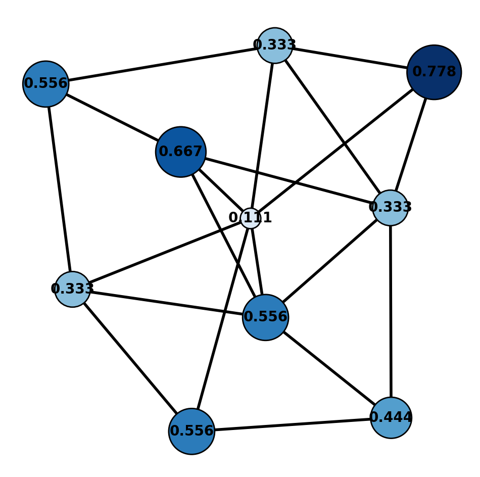

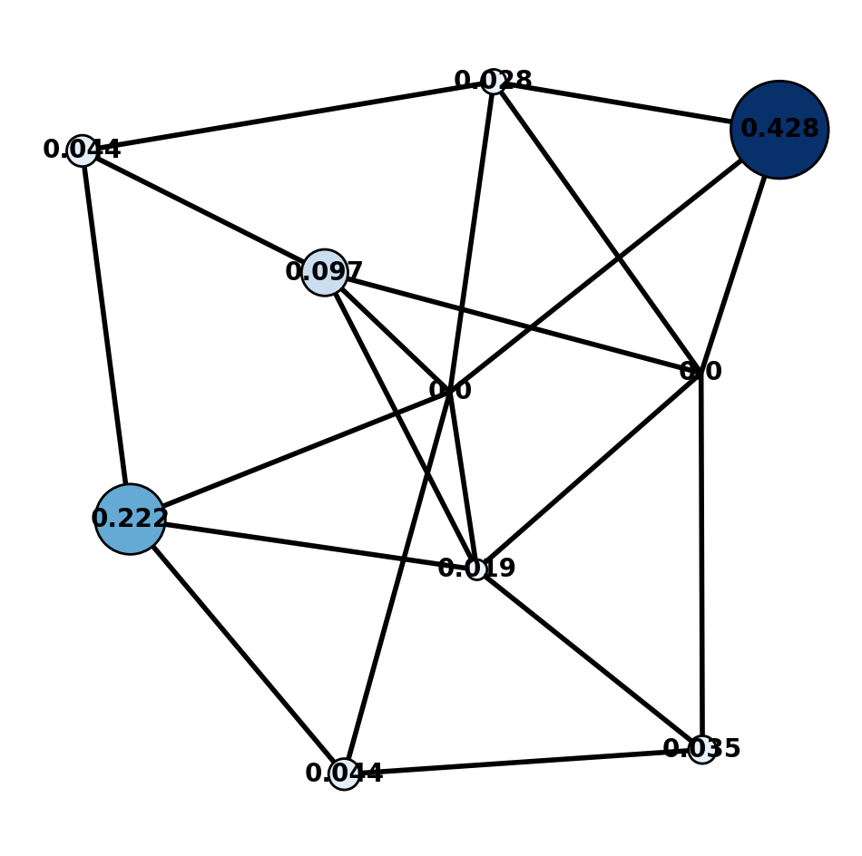

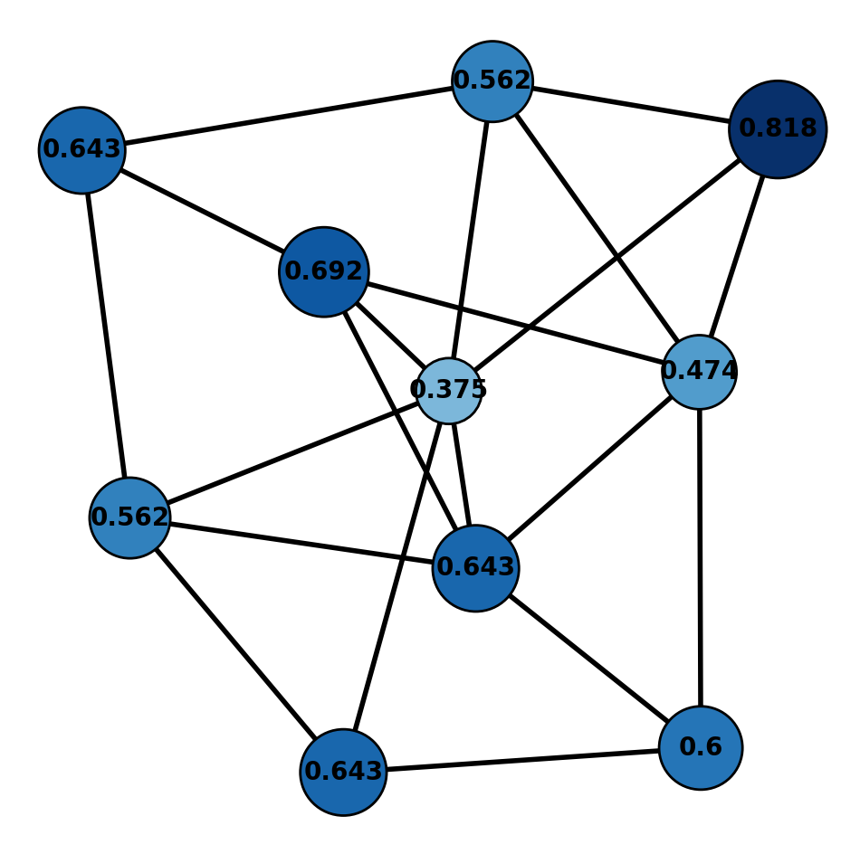

```python
import matplotlib.pyplot as plt
import random

# Create Centrality graphs to compare results and see what is significant visually
N=10
G = nx.gnp_random_graph(N, 0.4, seed = 10374196)

# Create Centrality values for each graph node
for i, node in enumerate(G.nodes()):
    G.nodes[node]['degree_centrality'] = centrality_df.iloc[i]['Degree Centrality']
    G.nodes[node]['betweeness_centrality'] = centrality_df.iloc[i]['Betweenness Centrality']
    G.nodes[node]['closeness_centrality'] = centrality_df.iloc[i]['Closeness Centrality']

pos = nx.spring_layout(G)

# Function for plot network for centrality measure
def plot_network(cmap, centrality_measure, font_color = 'black'):
    centrality = nx.get_node_attributes(G, centrality_measure)
    centrality_values = np.array(list(centrality.values()))
    node_size=6000*centrality_values/max(centrality_values)
    colors_n = [cmap(u/max(centrality_values)) for u in centrality_values]
    labels = {n: round(v,3) for n,v in centrality.items()}

    fig, ax = plt.subplots()
    fig.set_size_inches(12, 12)
    #PLOT
    nx.draw(
    G,
    node_color=colors_n,
    edgecolors="black",
    edge_color="black",
    linewidths=2,
    labels=labels,
    font_color=font_color,
    font_weight="bold",
    font_size=20,
    width=4,
    node_size=node_size,
    with_labels=True,
    pos=pos,
    ax=ax,
    )
    plt.show()

cmap = plt.cm.get_cmap('Blues')

# Plot networks
plot_network(cmap, 'degree_centrality', "black")
plot_network(cmap, 'betweeness_centrality', 'black')
plot_network(cmap, 'closeness_centrality', 'black')
```

```python
# To incorporate train and testing model for the centralities, will create a risk level to predict risk level

# Threshold numbers of high risk
degree_threshold = 0.5
bet_threshold = 0.1
closeness_threshold = 0.6

# Calculate risk level based on thresholds
centrality_df['Risk level'] = ((centrality_df['Degree Centrality']> degree_threshold) |
                               (centrality_df['Betweenness Centrality']> bet_threshold) |
                               (centrality_df['Closeness Centrality']> closeness_threshold)).astype(int)
centrality_df
```

|  | Degree Centrality | Betweenness Centrality | Closeness Centrality | Risk level |
| --- | --- | --- | --- | --- |
| fund_return_ytd | 0.333333 | 0.027778 | 0.562500 | 0 |
| fund_return_1month | 0.111111 | 0.000000 | 0.375000 | 0 |
| fund_return_3months | 0.333333 | 0.222222 | 0.562500 | 1 |
| fund_return_1year | 0.777778 | 0.428241 | 0.818182 | 1 |
| fund_return_3years | 0.555556 | 0.043981 | 0.642857 | 1 |
| fund_return_2020 | 0.333333 | 0.000000 | 0.473684 | 0 |
| fund_return_2019 | 0.666667 | 0.097222 | 0.692308 | 1 |
| fund_return_2018 | 0.444444 | 0.034722 | 0.600000 | 0 |
| fund_return_2017 | 0.555556 | 0.018519 | 0.642857 | 1 |
| fund_mean_annual_return_3years | 0.555556 | 0.043981 | 0.642857 | 1 |

```python
# Split the data
from sklearn.model_selection import train_test_split
from sklearn.linear_model import LogisticRegression

X = centrality_df[['Degree Centrality', 'Betweenness Centrality', 'Closeness Centrality']]
y = centrality_df['Risk level']

X_train, X_test, y_train, y_test = train_test_split(X, y, test_size = 0.2, random_state = 42)

# Use logisitc regression for simplisticy
model = LogisticRegression()

# Train model
model.fit(X_train, y_train)
```

```
LogisticRegression()
```